# Projet Statistique : Analyse des Émissions des Turbines à Gaz et Maintenance Prédictive

Groupe 5 : Ahmed Janenne | Chaima Mhedhbie | Salah Gouja | Salma Ferjani | Malek Jlassi | Mohamed Mohamed Salem

# Introduction

Ce notebook analyse les données sur les émissions de gaz des turbines (CO) collectées entre 2011 et 2015.  
L’objectif est d’explorer les relations entre les variables environnementales et les émissions, de réaliser des analyses statistiques approfondies et de construire des modèles prédictifs.

La méthodologie s’inspire de l’article *“ANOVA, Regression, Correlation Analysis: A Portfolio of Work in Statistical Techniques with SPSS”*.  
Contrairement à l’article, qui se concentre uniquement sur les données de 2015, ce notebook étend l’analyse à l’ensemble des données de 2011 à 2015.

En complément, ce notebook inclura également une analyse du dataset *AI4I 2020* sur la maintenance prédictive, permettant d’explorer les relations entre la qualité des produits, les défaillances des machines, et d’autres variables pertinentes.

# les données sur les émissions de gaz des turbines

## Chargement et Préparation des Données

```r
# Load necessary library
library(dplyr)

# File paths (update to your file system if needed)
file_2011 <- "gt_2011.csv"
file_2012 <-  "gt_2012.csv"
file_2013 <- "gt_2013.csv"
file_2014 <-  "gt_2014.csv"
file_2015 <- "gt_2015.csv"

# Read the CSV files
df_2011 <- read.csv(file_2011) %>% mutate(Year = 2011)
df_2012 <- read.csv(file_2012) %>% mutate(Year = 2012)
df_2013 <- read.csv(file_2013) %>% mutate(Year = 2013)
df_2014 <- read.csv(file_2014) %>% mutate(Year = 2014)
df_2015 <- read.csv(file_2015) %>% mutate(Year = 2015)

# Concatenate all files row-wise
data <- bind_rows(df_2011, df_2012, df_2013,df_2014,df_2015)


# View combined data
print(data)
```

| AT | AP | AH | AFDP | GTEP | TIT | TAT | TEY | CDP | CO | NOX | Year |
| --- | --- | --- | --- | --- | --- | --- | --- | --- | --- | --- | --- |
| 4.5878 | 1018.7 | 83.675 | 3.5758 | 23.979 | 1086.2 | 549.83 | 134.67 | 11.898 | 0.32663000 | 81.952 | 2011 |
| 4.2932 | 1018.3 | 84.235 | 3.5709 | 23.951 | 1086.1 | 550.05 | 134.67 | 11.892 | 0.44784000 | 82.377 | 2011 |
| 3.9045 | 1018.4 | 84.858 | 3.5828 | 23.990 | 1086.5 | 550.19 | 135.10 | 12.042 | 0.45144000 | 83.776 | 2011 |
| 3.7436 | 1018.3 | 85.434 | 3.5808 | 23.911 | 1086.5 | 550.17 | 135.03 | 11.990 | 0.23107000 | 82.505 | 2011 |
| 3.7516 | 1017.8 | 85.182 | 3.5781 | 23.917 | 1085.9 | 550.00 | 134.67 | 11.910 | 0.26747000 | 82.028 | 2011 |
| 3.8858 | 1017.7 | 83.946 | 3.5824 | 23.903 | 1086.0 | 549.98 | 134.67 | 11.868 | 0.23473000 | 81.748 | 2011 |
| 3.6697 | 1018.0 | 84.114 | 3.5804 | 23.889 | 1085.9 | 550.04 | 134.68 | 11.877 | 0.44412000 | 84.592 | 2011 |
| 3.5892 | 1018.2 | 83.867 | 3.5777 | 23.876 | 1086.0 | 549.88 | 134.66 | 11.893 | 0.79996000 | 84.193 | 2011 |
| 3.7108 | 1018.5 | 84.948 | 3.6027 | 23.957 | 1086.3 | 549.98 | 134.65 | 11.870 | 0.68996000 | 83.978 | 2011 |
| 4.8281 | 1018.5 | 85.346 | 3.5158 | 23.422 | 1083.1 | 549.80 | 132.67 | 11.694 | 1.02810000 | 82.654 | 2011 |

[output cut: 990 more lines]

```r
# write the dataset in data file (one execution)
#write.csv(data, "data.csv", row.names = FALSE)

# View the structure of the dataset
str(data)
```

```
'data.frame':   36733 obs. of  12 variables:
 $ AT  : num  4.59 4.29 3.9 3.74 3.75 ...
 $ AP  : num  1019 1018 1018 1018 1018 ...
 $ AH  : num  83.7 84.2 84.9 85.4 85.2 ...
 $ AFDP: num  3.58 3.57 3.58 3.58 3.58 ...
 $ GTEP: num  24 24 24 23.9 23.9 ...
 $ TIT : num  1086 1086 1086 1086 1086 ...
 $ TAT : num  550 550 550 550 550 ...
 $ TEY : num  135 135 135 135 135 ...
 $ CDP : num  11.9 11.9 12 12 11.9 ...
 $ CO  : num  0.327 0.448 0.451 0.231 0.267 ...
 $ NOX : num  82 82.4 83.8 82.5 82 ...
 $ Year: num  2011 2011 2011 2011 2011 ...
```

```r
# Check column names
colnames(data)
```

```
 [1] "AT"   "AP"   "AH"   "AFDP" "GTEP" "TIT"  "TAT"  "TEY"  "CDP"  "CO"   "NOX"  "Year"
```

```r
# Afficher un aperçu des données
head(data)
```

|  | AT | AP | AH | AFDP | GTEP | TIT | TAT | TEY | CDP | CO | NOX | Year |
| --- | --- | --- | --- | --- | --- | --- | --- | --- | --- | --- | --- | --- |
| 1 | 4.5878 | 1018.7 | 83.675 | 3.5758 | 23.979 | 1086.2 | 549.83 | 134.67 | 11.898 | 0.32663 | 81.952 | 2011 |
| 2 | 4.2932 | 1018.3 | 84.235 | 3.5709 | 23.951 | 1086.1 | 550.05 | 134.67 | 11.892 | 0.44784 | 82.377 | 2011 |
| 3 | 3.9045 | 1018.4 | 84.858 | 3.5828 | 23.990 | 1086.5 | 550.19 | 135.10 | 12.042 | 0.45144 | 83.776 | 2011 |
| 4 | 3.7436 | 1018.3 | 85.434 | 3.5808 | 23.911 | 1086.5 | 550.17 | 135.03 | 11.990 | 0.23107 | 82.505 | 2011 |
| 5 | 3.7516 | 1017.8 | 85.182 | 3.5781 | 23.917 | 1085.9 | 550.00 | 134.67 | 11.910 | 0.26747 | 82.028 | 2011 |
| 6 | 3.8858 | 1017.7 | 83.946 | 3.5824 | 23.903 | 1086.0 | 549.98 | 134.67 | 11.868 | 0.23473 | 81.748 | 2011 |

```r
# Display the last few rows
tail(data)
```

|  | AT | AP | AH | AFDP | GTEP | TIT | TAT | TEY | CDP | CO | NOX | Year |
| --- | --- | --- | --- | --- | --- | --- | --- | --- | --- | --- | --- | --- |
| 36728 | 3.3776 | 1028.5 | 92.703 | 3.3128 | 20.248 | 1057.6 | 550.30 | 117.46 | 10.783 | 5.3488 | 66.550 | 2015 |
| 36729 | 3.6268 | 1028.5 | 93.200 | 3.1661 | 19.087 | 1037.0 | 541.59 | 109.08 | 10.411 | 10.9930 | 89.172 | 2015 |
| 36730 | 4.1674 | 1028.6 | 94.036 | 3.1923 | 19.016 | 1037.6 | 542.28 | 108.79 | 10.344 | 11.1440 | 88.849 | 2015 |
| 36731 | 5.4820 | 1028.5 | 95.219 | 3.3128 | 18.857 | 1038.0 | 543.48 | 107.81 | 10.462 | 11.4140 | 96.147 | 2015 |
| 36732 | 5.8837 | 1028.7 | 94.200 | 3.9831 | 23.563 | 1076.9 | 550.11 | 131.41 | 11.771 | 3.3134 | 64.738 | 2015 |
| 36733 | 6.0392 | 1028.8 | 94.547 | 3.8752 | 22.524 | 1067.9 | 548.23 | 125.41 | 11.462 | 11.9810 | 109.240 | 2015 |

```r
# Get the dimensions (rows and columns)
dim(data)
```

```
[1] 36733    12
```

```r
# Summary statistics for the entire dataset
summary(data)
```

```
       AT               AP               AH              AFDP            GTEP            TIT            TAT             TEY             CDP
 Min.   :-6.235   Min.   : 985.9   Min.   : 24.09   Min.   :2.087   Min.   :17.70   Min.   :1001   Min.   :511.0   Min.   :100.0   Min.   : 9.852
 1st Qu.:11.781   1st Qu.:1008.8   1st Qu.: 68.19   1st Qu.:3.356   1st Qu.:23.13   1st Qu.:1072   1st Qu.:544.7   1st Qu.:124.5   1st Qu.:11.435
 Median :17.801   Median :1012.6   Median : 80.47   Median :3.938   Median :25.10   Median :1086   Median :549.9   Median :133.7   Median :11.965
 Mean   :17.713   Mean   :1013.1   Mean   : 77.87   Mean   :3.926   Mean   :25.56   Mean   :1081   Mean   :546.2   Mean   :133.5   Mean   :12.061
 3rd Qu.:23.665   3rd Qu.:1017.0   3rd Qu.: 89.38   3rd Qu.:4.377   3rd Qu.:29.06   3rd Qu.:1097   3rd Qu.:550.0   3rd Qu.:144.1   3rd Qu.:12.855
 Max.   :37.103   Max.   :1036.6   Max.   :100.20   Max.   :7.611   Max.   :40.72   Max.   :1101   Max.   :550.6   Max.   :179.5   Max.   :15.159
       CO                NOX              Year
 Min.   : 0.00039   Min.   : 25.91   Min.   :2011
 1st Qu.: 1.18240   1st Qu.: 57.16   1st Qu.:2012
 Median : 1.71350   Median : 63.85   Median :2013
 Mean   : 2.37247   Mean   : 65.29   Mean   :2013
 3rd Qu.: 2.84290   3rd Qu.: 71.55   3rd Qu.:2014
 Max.   :44.10300   Max.   :119.91   Max.   :2015
```

```r
# Summary for specific columns
#summary(data$TAT)  # Replace 'AT' with a column name   #hedhi bedhet zayda wadh7a eli wa7ed yet3alm mn 3and tchat

# Check unique values in categorical columns
unique(data$Year)
```

```
[1] 2011 2012 2013 2014 2015
```

Les statistiques descriptives ci-dessus fournissent un aperçu des variables du dataset, montrant la gamme des valeurs (min, max), ainsi que des mesures de tendance centrale (moyenne, médiane) pour chaque variable. Cela permet de mieux comprendre la distribution des données avant d’entamer les analyses statistiques plus approfondies.

```r
# Check for missing values in each column
colSums(is.na(data))
```

```
  AT   AP   AH AFDP GTEP  TIT  TAT  TEY  CDP   CO  NOX Year
   0    0    0    0    0    0    0    0    0    0    0    0
```

Les données ne contiennent aucune valeur manquante, comme le montre l’absence de valeurs “NA” dans toutes les colonnes.

## Analyse des Relations entre les Variables Indépendantes et les Variables Dépendantes

Dans cette section on va implémenter des graphiques pour visualiser la relation entre chaque variable indépendante et les variables dépendantes (CO et NOx). Nous utilisons ici des graphiques de dispersion pour observer comment chaque variable indépendante (par exemple, la température, la pression) est liée aux émissions de CO et NOx. À chaque fois, les paramètres de la fonction ‘plot’ sont ajustés pour représenter correctement ces relations.

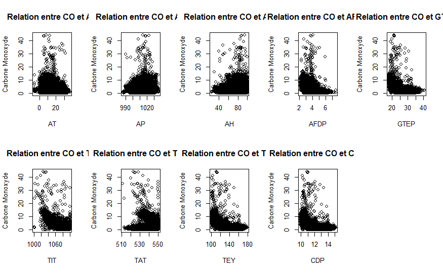

```r
par(mfrow = c(2, 5))

# Liste des variables indépendantes
variables <- c("AT", "AP", "AH", "AFDP", "GTEP", "TIT", "TAT", "TEY","CDP")

# Utilisation de lapply pour créer les graphiques
invisible(lapply(variables, function(var) {
  plot(data[[var]], data$CO,
       xlab = paste(var),
       ylab = "Carbone Monoxyde",
       main = paste("Relation entre CO et", var))
}))
```

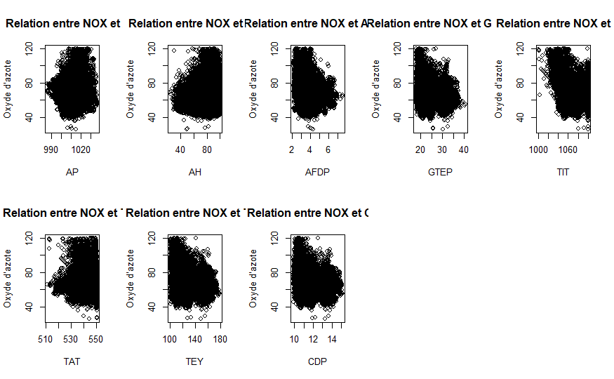

```r
invisible(lapply(variables, function(var) {
  plot(data[[var]], data$NOX,
       xlab = paste(var),
       ylab = "Oxyde d'azote",
       main = paste("Relation entre NOX et", var))
}))
```

D’après les graphiques de dispersion, aucune relation linéaire évidente n’émerge entre les variables indépendantes (comme la température, la pression, etc.) et les émissions de CO et NOx. Cette absence de relation linéaire suggère que les données peuvent suivre une tendance monotone mais non linéaire. Ainsi, nous allons appliquer le test de corrélation de Spearman (apres avoir tester la normlité ), qui est une méthode non paramétrique, pour évaluer la force et la direction des relations monotones entre ces variables.

## Visualisation des Relations entre les Variables Indépendantes et les Variables Dépendantes

Graphiques de dispersion pour les relations entre les variables indépendantes et les variables dépendantes (CO et NOX)

```r
#
par(mfrow = c(3, 3))  # Organiser les scatter plots en 3 lignes et 3 colonnes

# Relation entre AT et CO
plot(data$AT, data$CO,
     xlab = "AT",                 # Légende de l'axe x
     ylab = "CO",                 # Légende de l'axe y
     main = "Relation entre AT et CO", # Titre du graphique
     col = "blue",                # Couleur des points
     pch = 19)                    # Type de points (19 pour des points pleins)

# Relation entre AP et CO
plot(data$AP, data$CO,
     xlab = "AP",                 # Légende de l'axe x
     ylab = "CO",                 # Légende de l'axe y
     main = "Relation entre AP et CO", # Titre du graphique
     col = "blue",                # Couleur des points
     pch = 19)                    # Type de points (19 pour des points pleins)
```

```r
# Relation entre AH et CO
plot(data$AH, data$CO,
     xlab = "AH",                 # Légende de l'axe x
     ylab = "CO",                 # Légende de l'axe y
     main = "Relation entre AH et CO", # Titre du graphique
     col = "blue",                # Couleur des points
     pch = 19)                    # Type de points (19 pour des points pleins)

# Relation entre AFDP et CO
plot(data$AFDP, data$CO,
     xlab = "AFDP",               # Légende de l'axe x
     ylab = "CO",                 # Légende de l'axe y
     main = "Relation entre AFDP et CO", # Titre du graphique
     col = "blue",                # Couleur des points
     pch = 19)                    # Type de points (19 pour des points pleins)
```

```r
# Relation entre GTEP et CO
plot(data$GTEP, data$CO,
     xlab = "GTEP",               # Légende de l'axe x
     ylab = "CO",                 # Légende de l'axe y
     main = "Relation entre GTEP et CO", # Titre du graphique
     col = "blue",                # Couleur des points
     pch = 19)                    # Type de points (19 pour des points pleins)

# Relation entre TIT et CO
plot(data$TIT, data$CO,
     xlab = "TIT",                # Légende de l'axe x
     ylab = "CO",                 # Légende de l'axe y
     main = "Relation entre TIT et CO", # Titre du graphique
     col = "blue",                # Couleur des points
     pch = 19)                    # Type de points (19 pour des points pleins)
```

```r
# Relation entre TAT et CO
plot(data$TAT, data$CO,
     xlab = "TAT",                # Légende de l'axe x
     ylab = "CO",                 # Légende de l'axe y
     main = "Relation entre TAT et CO", # Titre du graphique
     col = "blue",                # Couleur des points
     pch = 19)                    # Type de points (19 pour des points pleins)

# Relation entre CDP et CO
plot(data$CDP, data$CO,
     xlab = "CDP",                # Légende de l'axe x
     ylab = "CO",                 # Légende de l'axe y
     main = "Relation entre CDP et CO", # Titre du graphique
     col = "blue",                # Couleur des points
     pch = 19)                    # Type de points (19 pour des points pleins)
```

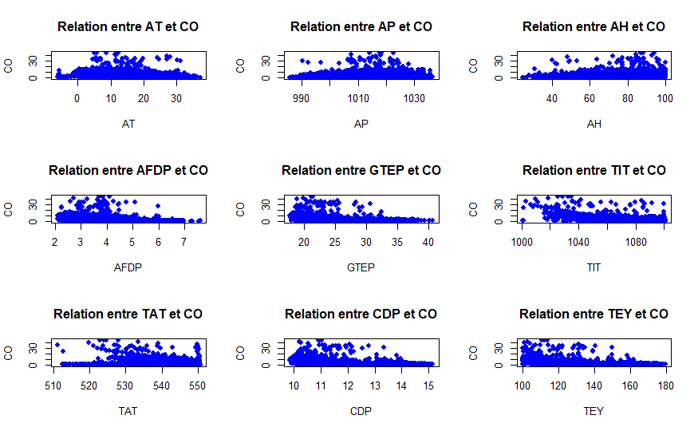

```r
# Relation entre TEY et CO
plot(data$TEY, data$CO,
     xlab = "TEY",                # Légende de l'axe x
     ylab = "CO",                 # Légende de l'axe y
     main = "Relation entre TEY et CO", # Titre du graphique
     col = "blue",                # Couleur des points
     pch = 19)                    # Type de points (19 pour des points pleins)
```

#=========================== meme code pour NOX ==============================================

```r
#
par(mfrow = c(3, 3))  # Organiser les scatter plots en 3 lignes et 3 colonnes

# Relation entre AT et NOX
plot(data$AT, data$NOX,
     xlab = "AT",                 # Légende de l'axe x
     ylab = "NOX",                 # Légende de l'axe y
     main = "Relation entre AT et NOX", # Titre du graphique
     col = "blue",                # Couleur des points
     pch = 19)                    # Type de points (19 pour des points pleins)

# Relation entre AP et NOX
plot(data$AP, data$NOX,
     xlab = "AP",                 # Légende de l'axe x
     ylab = "NOX",                 # Légende de l'axe y
     main = "Relation entre AP et NOX", # Titre du graphique
     col = "blue",                # Couleur des points
     pch = 19)                    # Type de points (19 pour des points pleins)
```

```r
# Relation entre AH et NOX
plot(data$AH, data$NOX,
     xlab = "AH",                 # Légende de l'axe x
     ylab = "NOX",                 # Légende de l'axe y
     main = "Relation entre AH et NOX", # Titre du graphique
     col = "blue",                # Couleur des points
     pch = 19)                    # Type de points (19 pour des points pleins)

# Relation entre AFDP et NOX
plot(data$AFDP, data$NOX,
     xlab = "AFDP",               # Légende de l'axe x
     ylab = "NOX",                 # Légende de l'axe y
     main = "Relation entre AFDP et NOX", # Titre du graphique
     col = "blue",                # Couleur des points
     pch = 19)                    # Type de points (19 pour des points pleins)
```

```r
# Relation entre GTEP et NOX
plot(data$GTEP, data$NOX,
     xlab = "GTEP",               # Légende de l'axe x
     ylab = "NOX",                 # Légende de l'axe y
     main = "Relation entre GTEP et NOX", # Titre du graphique
     col = "blue",                # Couleur des points
     pch = 19)                    # Type de points (19 pour des points pleins)

# Relation entre TIT et NOX
plot(data$TIT, data$NOX,
     xlab = "TIT",                # Légende de l'axe x
     ylab = "NOX",                 # Légende de l'axe y
     main = "Relation entre TIT et NOX", # Titre du graphique
     col = "blue",                # Couleur des points
     pch = 19)                    # Type de points (19 pour des points pleins)
```

```r
# Relation entre TAT et NOX
plot(data$TAT, data$NOX,
     xlab = "TAT",                # Légende de l'axe x
     ylab = "NOX",                 # Légende de l'axe y
     main = "Relation entre TAT et NOX", # Titre du graphique
     col = "blue",                # Couleur des points
     pch = 19)                    # Type de points (19 pour des points pleins)

# Relation entre CDP et NOX
plot(data$CDP, data$NOX,
     xlab = "CDP",                # Légende de l'axe x
     ylab = "NOX",                 # Légende de l'axe y
     main = "Relation entre CDP et NOX", # Titre du graphique
     col = "blue",                # Couleur des points
     pch = 19)                    # Type de points (19 pour des points pleins)
```

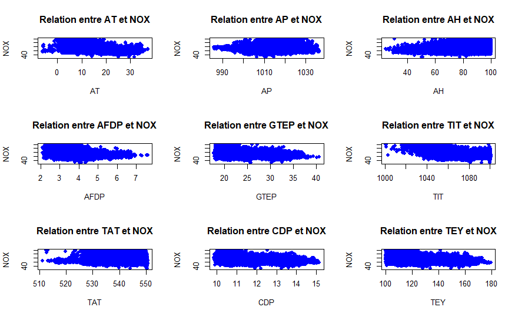

```r
# Relation entre TEY et NOX
plot(data$TEY, data$NOX,
     xlab = "TEY",                # Légende de l'axe x
     ylab = "NOX",                 # Légende de l'axe y
     main = "Relation entre TEY et NOX", # Titre du graphique
     col = "blue",                # Couleur des points
     pch = 19)                    # Type de points (19 pour des points pleins)
```